# A2 - Análisis estadístico I

Yésica Fernández

2022-04-22

Antes de empezar con el preprocesado de datos, vamos a cargar los paquetes necesarios para la realización del ejercicio.

```r
# https://cran.r-project.org/web/packages/dplyr/index.html
if (!require('dplyr')) install.packages('dplyr'); library('dplyr')
# https://cran.r-project.org/web/packages/ggplot2/index.html
if (!require('ggplot2')) install.packages('ggplot2'); library('ggplot2')
# https://cran.r-project.org/web/packages/graphics/index.html
if (!require('graphics')) install.packages('graphics'); library('graphics')
```

#1.- Lectura del fichero y preparación de los datos

En primer lugar, se carga el csv de datos para poder trabajar con el.

```r
Censo <- read.csv("CensusIncome_clean.csv", sep = ",", stringsAsFactors = TRUE)
```

Se verifica que los datos se han cargado correctamente.

```r
summary(Censo)
```

```
##      CS_ID            age                workclass     education_num
##  CS1    :    1   Min.   :17.00   Government   : 4349   Min.   : 1.00
##  CS10   :    1   1st Qu.:28.00   Other/Unknown: 1855   1st Qu.: 9.00
##  CS100  :    1   Median :37.00   Private      :22692   Median :10.00
##  CS1000 :    1   Mean   :38.55   Self-Employed: 3657   Mean   :10.08
##  CS10000:    1   3rd Qu.:48.00                         3rd Qu.:12.00
##  CS10001:    1   Max.   :80.00                         Max.   :16.00
##  (Other):32547
##  marital_status         relationship           occupation
##  D: 4442        Husband       :13192   Blue-Collar  :10060
##  M:15413        Not-in-family : 8303   Other/Unknown: 1850
##  S:10680        Other-relative:  981   Professional : 4139
##  W:  993        Own-child     : 5067   Sales        : 3649
##  X: 1025        Unmarried     : 3444   Service      : 5021
##                 Wife          : 1566   White-Collar : 7834
##
##                  race       gender    hours_per_week      income
##  Amer-Indian-Eskimo:  311   f:10767   Min.   : 1.00   Min.   : 0.10
##  Asian-Pac-Islander: 1039   m:21786   1st Qu.:40.00   1st Qu.:43.22
##  Black             : 3123             Median :40.50   Median :49.71
##  Other             :  271             Mean   :40.31   Mean   :48.75
##  White             :27809             3rd Qu.:45.00   3rd Qu.:54.32
##                                       Max.   :80.00   Max.   :68.37
##
##            education_cat
##  Postuniversitaria: 2712
##  Primaria         : 2644
##  Secundaria       :12106
##  Universitaria    :15091
##
##
##
```

# 2.- Edad

Es interesante conocer el valor medio de la edad del censo, por lo que se va a calcular el intervalo de confianza de la media edad.

## 2.1- Distribución de edades

Se va a visualizar gráficamente la distribución de la edad.

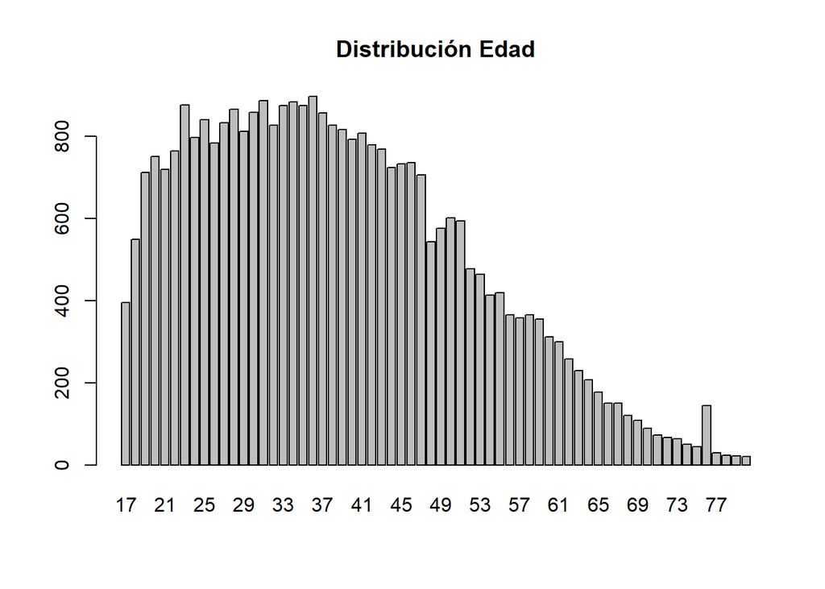

```r
barplot(table(Censo$age), main= "Distribución Edad")
```

Se observa en el gráfico que la mayoría se encuentra entre los 20 y los 40 años.

## 2.2.- Normalidad

Para comprobar si la edad sigue una distribución normal, en primer lugar se va a calcular la media y la desviación estándar y se va a realizar la representación en una curva.

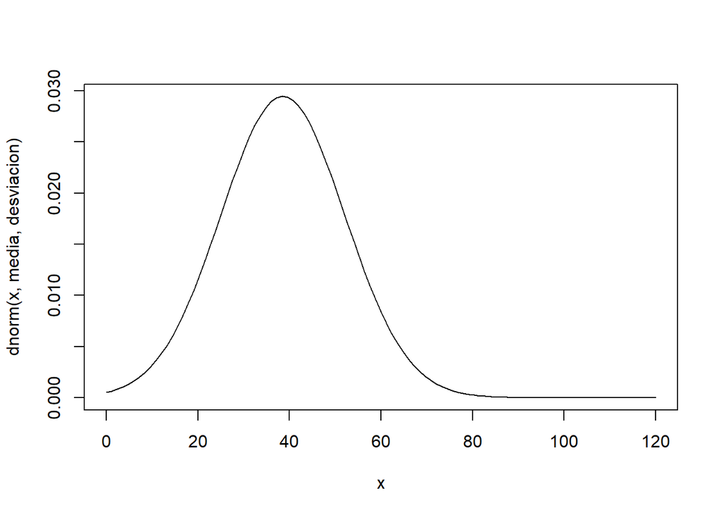

```r
media <- mean(Censo$age)
desviacion <- sd(Censo$age)
curve(dnorm(x, media, desviacion), xlim = c(0, 120))
```

## 2.3.- Intervalo de confianza

Para calcular el intervalo de confianza de la media de la variable edad se va a definir una función IC que reciba la variable y la confianza y que devuelva un vector con los valores del intervalo de confianza.

A pesar de no seguir una distribución normal, como la población tiene una medida superior a 30, podemos seguir el mismo método para el cálculo de los intervalos de confianza.

```r
IC <- function(x, NC){
  alpha <- 1 - NC
  n <- length(x)
  desviacion <- sd(x)
  media <- mean(x)
  cuartil <- qt(alpha/2, df=n-1,  lower.tail=FALSE)
  margen_error = abs((cuartil*desviacion) / sqrt(n))
  lim_inf <- media - margen_error
  lim_sup <- media + margen_error
  a <- c(lim_inf, lim_sup)
  return(a)
}
```

## 2.4.- Cálculos

Una vez que se ha definido la función, se va a calcular el intervalo de confianza al 90% y al 95%.

```r
Resultado_1 <- IC(Censo$age, 0.95)
Resultado_1
```

```
## [1] 38.40276 38.69698
```

```r
Resultado_2 <- IC(Censo$age, 0.90)
Resultado_2
```

```
## [1] 38.42642 38.67333
```

Se oberva que con un intervalo de confianza superior el porcentaje de rechazo, alpha, es inferior (pasa de 0.1 a 0.05), lo que implica que la región de aceptación es mayor.

# 3.- Salario

Se va a investigar ahora el salario de la población. En particular, la pregunta es que si en media, el salario de las personas Self-Employed es inferior al resto de modalidades.

## 3.1. Pregunta de investigación

¿La media del salario de las personas Self-Employed es inferior al resto de personas de la población?

## 3.2.- Hipótesis

$$\left\{
\begin{array}{ll}
H_{0}: & \mu_{0}=\mu_{1}\\
H_{1}: & \mu_{0} <\mu_{1}
\end{array}
\right.$$

Siendo $\mu_{0}$ la media del salario en personas Self-Employed y $\mu_{1}$ en el resto de la población. Proponemos como $H_0$ que las medias del salario entre personas Self-Employed y el resto de la población es la misma, y como hipótesis alternativa, que es inferior.

## 3.3.- Test a aplicar

En primer lugar, para saber que test podemos utilizar, vamos a observar si la variable sigue una distribución normal.

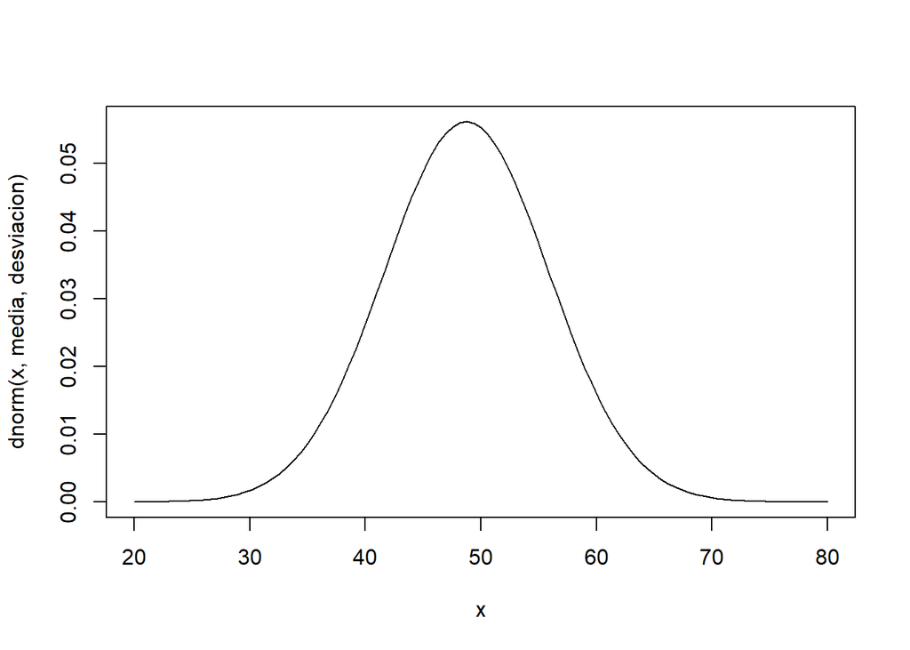

```r
media <- mean(Censo$income)
desviacion <- sd(Censo$income)
curve(dnorm(x, media, desviacion), xlim = c(20, 80))
```

Podemos asumir normalidad en el salario y por lo tanto se puede calcular la probabilidad de que varios valores ocurran en un cierto intervalo dada la confianza, por lo que se puede afirmar que se trata de un test paramétrico.

Por otra parte, es un contraste de dos muestras independientes.

## 3.4.- Cálculo

Para el cálculo del test se va a implementar una función propia.

```r
my_test_3 <- function(x, y, NC){
  media_x <- mean(x)
  media_y <- mean(y)
  var_x <- var(x)
  var_y <- var(y)
  alpha <- 1 - NC
  n_x <- length(x)
  n_y <- length(y)
  #Estadístico de contraste
  zobs <- (media_x - media_y) / sqrt((var_x/n_x) + (var_y/n_y))
  #Región de aceptación
  zcrit.L <- qnorm(1-alpha, lower.tail=TRUE)
  #Cálculo del p valor
  pvalue <- pnorm(zobs, lower.tail=TRUE,)
  return(data.frame(L=zcrit.L, U="INF", zobs, pvalue))
}
```

Una vez que tenemos definida la función, vamos a calcular la media del salario de la población que no es Self-Employed.

```r
mu <- mean(filter(Censo, workclass != "Self-Employed" )$income)
mu
```

```
## [1] 48.67183
```

Una vez tenemos el valor de la media, vamos a calcular el contraste para un nivel de confianza del 95% y del 90%.

```r
Resultado_3 <- my_test_3(filter(Censo, workclass == "Self-Employed" )$income, filter(Censo, workclass != "Self-Employed" )$income, 0.95)
Resultado_4 <- my_test_3(filter(Censo, workclass == "Self-Employed" )$income, filter(Censo, workclass != "Self-Employed" )$income, 0.90)
Resultado_3$NivelConfianza <- "95%"
Resultado_4$NivelConfianza <- "90%"
Resultados <- rbind(Resultado_4, Resultado_3)
knitr::kable(Resultados)
```

| L | U | zobs | pvalue | NivelConfianza |
| --- | --- | --- | --- | --- |
| 1.281552 | INF | 6.88972 | 1 | 90% |
| 1.644854 | INF | 6.88972 | 1 | 95% |

## 3.5.- Conclusión

Con un nivel de confianza del 90%, dado que p-valor > $\alpha$, aceptamos la hipótesis nula y se concluye que la media de salario de la población Self-Employed es igual a la media de salario del resto de la población.

Con un nivel de confianza del 95% obtenemos el mismo resultado que con el nivel de confianza inferior.

# 4.- Proporción de Self-employed

La pregunta es si el porcentaje de Self-Employed en la población es superior al 10%.

## 4.1.- Pregunta

¿La proporción de Self-Employed de la población es superior al 10%?

## 4.2.- Hipótesis

$$\left\{
\begin{array}{ll}
H_{0}: & p=0.10\\
H_{1}: & p>0.10
\end{array}
\right.$$

Siendo p la proporción de la población Self-Employed, se propone como $H_0$ que la proporción es igual al 10%, y como hipótesis alternativa, que es superior.

## 4.3. - Análisis visual

Se va a representar de forma gráfica la proporción de Self-Employed de la muestra. Para ello, se va a utilizar un gráfico de sectores.

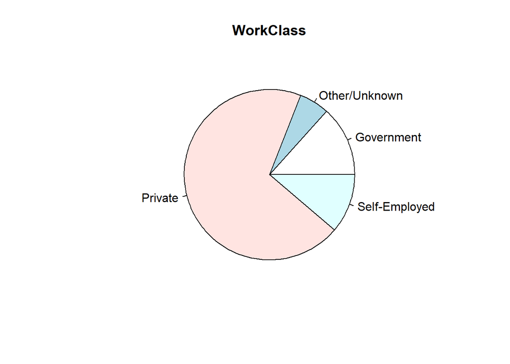

```r
pie(table(Censo$workclass), main = "WorkClass")
```

## 4.4.- Contraste

Dada la formulación de hipótesis alternativa, se trata de un test unilateral por la derecha.

## 4.5.- Cálculo

Para realizar el cálculo se va a implementar una función propia.

```r
my_test_4 <- function(x, y, NC, mu){
  n <- length(x)
  Self <- length(y)
  proporcion <- Self/n
  q <- 1 - mu
  #Calculo del nivel de significación
  alpha <- 1- NC
  #Región de aceptación
  tcrit.L <- qnorm(alpha, lower.tail = FALSE)
  #Estadístico de contraste
  tobs <- (proporcion - mu) / sqrt((mu*(1-mu))/n)
  #Cálculo del p valor
  pvalue <- pnorm(tobs, lower.tail=FALSE)
  return(data.frame(L=tcrit.L, U="INF", tobs, pvalue))
}
```

Una vez tenemos la función, calculamos para un nivel de confianza del 95%.

```r
Resultado_5 <- my_test_4(Censo$workclass, filter(Censo, workclass == "Self-Employed" )$workclass, 0.95, 0.10)
Resultado_5$NivelConfianza <- "95%"
knitr::kable(Resultado_5)
```

| L | U | tobs | pvalue | NivelConfianza |
| --- | --- | --- | --- | --- |
| 1.644854 | INF | 7.421387 | 0 | 95% |

# 5.- Proporción de Self-Employed en mujeres y hombres

Nos preguntamos si la proporción de Self-Employed es menor entre las mujeres que entre los hombres en la población.

## 5.1.- Pregunta de investigación

¿La proporción de Self-Employed en la población es menor entre las mujeres que entre los hombres?

## 5.2.- Análisis visual

Vamos a representar la proporción de Self-Employed en la muestra de hombres y en la muestra de mujeres.

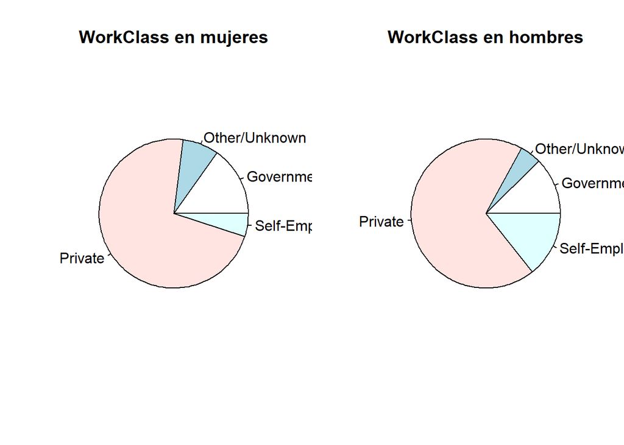

```r
par(mfrow = c(1,2))
pie(table(filter(Censo, gender == "f")$workclass), main = "WorkClass en mujeres")
pie(table(filter(Censo, gender == "m")$workclass), main = "WorkClass en hombres")
```

A simple vista ya se observa que la proporción de Self-employed en mujeres es menor que en los hombres.

## 5.3.- Hipótesis

$$\left\{
\begin{array}{ll}
H_{0}: & \mu_{0}=\mu_{1}\\
H_{1}: & \mu_{0} <\mu_{1}
\end{array}
\right.$$

Siendo $\mu_{0}$ la proporción de Self-Employed en mujeres y $\mu_{1}$ la proporción en hombres, se propone como $H_0$ que las proporciones entre los dos géneros son la misma, y como hipótesis alternativa, que es la propoción es inferior en mujeres.

## 5.4. Test

Se trata de un contraste de dos muestra. Y, además, es un contraste unilateral por la izquierda, puesto que hay que observar una evidencia suficiente de que sea notablemente inferior a la media de la población que no es Self-Employed.

## 5.5.- Cálculo

Definimos una función para el cálculo del contraste.

```r
my_test_5 <- function(x, y, NC, total){
  alpha <- 1 - NC
  n_x <- length(x)
  n_y <- length(y)
  p_x <- n_x / total
  p_y <- n_y / total
  p <- (n_x*p_x + n_y*p_y) / (n_x+n_y)
  zobs <- (p_x -p_y) / (sqrt(p*(1-p)*(1/n_x + 1/n_y)))
  zcrit.L <- qnorm (alpha, lower.tail = TRUE)
  pvalue <- pnorm (zobs, lower.tail = TRUE)
  return(data.frame(L=zcrit.L, U="-INF", zobs, pvalue))
}
```

Una vez definida la función, realizamos el cálculo con un nivel de confianza del 97%.

```r
Resultado_6 <- my_test_5(filter(Censo, workclass == "Self-Employed" & gender == "f")$workclass, filter(Censo, workclass == "Self-Employed" & gender == "m")$workclass, 0.97, length(Censo$workclass))
Resultado_6$NivelConfianza <- "97%"
knitr::kable(Resultado_6)
```

| L | U | zobs | pvalue | NivelConfianza |
| --- | --- | --- | --- | --- |
| -1.880794 | -INF | -6.112124 | 0 | 97% |

## 5.6.- Conclusión

Con un nivel de confianza del 97%, como el valor observado no se encuentra en el intervalo de confianza podemos rechazar la hipótesis nula. Por otra parte, como p-value < $\alpha$ también podemos aceptar la rechazar nula. Por lo tanto, se confirma que la hipótesis alternativa, la proporción de Self-Employed en mujeres es menor que en hombres.